# Statistics for Data Science Project 2021/2022 - Risk of Business Failure

Question A

# Data Preparation

We load the necessary libraries as well as the aida dataset itself, along with any needed variable obtained during the first section.

```r
library(ggplot2)
library(dplyr)
```

```r
# cleaning the environment
rm(list=ls())
# loading the dataset
load(file="aida.RData")
# loading functions to be used
source("functions.R")
```

```r
# features added by using the functions in "functions.R"
aida <- getSize(aida)
aida <- getGeoArea(aida)
aida <- getStatus(aida)
aida <- getAge(aida)
aida <- getATECO(aida)
aida <- getLiquidity(aida)
# separating dataset filtering by year
aida.currYr <- getCurrYr(aida)
aida.yr1 <- getYr1(aida)
aida.yr2 <- getYr2(aida)
# focusing on a specific year
aida2018 <- aida.currYr[aida.currYr$`Last accounting closing date` == 2018,]
```

# 2.0 Question A

Compare the distributions of size/age/other between failed and active companies at a specific year?

- do they change for a specific company form (SPA, SRL, etc.)
- do they change for a specific industry sector? (see ATECO sectors)

## 2.1 Age Distribution

Let us look at the density function of the *Age* feature we obtained before at certain years, namely 2018, since that is the year where we have the biggest amount of information available.

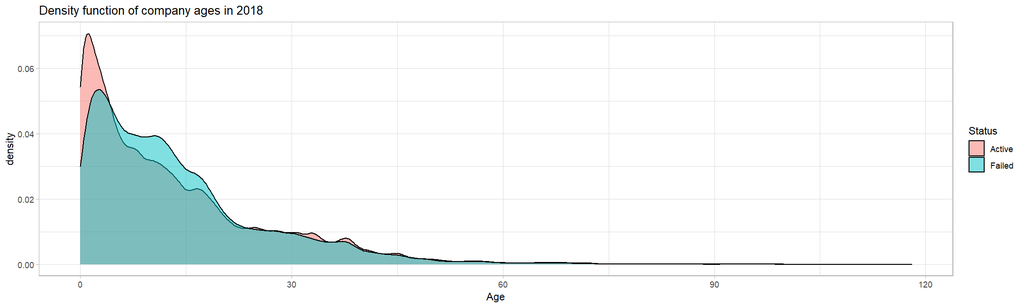

```r
# density of age in 2018
ggplot(data=aida2018, aes(x=Age, fill=Status)) +
  geom_density(alpha=.5) +
  theme_light() +
  ggtitle("Density function of company ages in 2018")
```

```r
# data for statistical tests, age distribution in 2018
aida2018.ActiveAge <- aida2018[aida2018$Status=='Active','Age']
aida2018.FailedAge <- aida2018[aida2018$Status=='Failed','Age']

wilcox.test(aida2018.ActiveAge, aida2018.FailedAge, alternative = 'two.sided')
```

```
    Wilcoxon rank sum test with continuity correction

data:  aida2018.ActiveAge and aida2018.FailedAge
W = 2.5729e+10, p-value < 2.2e-16
alternative hypothesis: true location shift is not equal to 0
```

```r
wilcox.test(aida2018.ActiveAge, aida2018.FailedAge, alternative = 'less')
```

```
    Wilcoxon rank sum test with continuity correction

data:  aida2018.ActiveAge and aida2018.FailedAge
W = 2.5729e+10, p-value < 2.2e-16
alternative hypothesis: true location shift is less than 0
```

```r
wilcox.test(aida2018.ActiveAge, aida2018.FailedAge, alternative = 'greater')
```

```
    Wilcoxon rank sum test with continuity correction

data:  aida2018.ActiveAge and aida2018.FailedAge
W = 2.5729e+10, p-value = 1
alternative hypothesis: true location shift is greater than 0
```

```r
t.test(aida2018.ActiveAge, aida2018.FailedAge, alternative = 'two.sided')
```

```
    Welch Two Sample t-test

data:  aida2018.ActiveAge and aida2018.FailedAge
t = -6.73, df = 84947, p-value = 1.707e-11
alternative hypothesis: true difference in means is not equal to 0
95 percent confidence interval:
 -0.4352665 -0.2389218
sample estimates:
mean of x mean of y
 13.53992  13.87701
```

```r
t.test(aida2018.ActiveAge, aida2018.FailedAge, alternative = 'less')
```

```
    Welch Two Sample t-test

data:  aida2018.ActiveAge and aida2018.FailedAge
t = -6.73, df = 84947, p-value = 8.536e-12
alternative hypothesis: true difference in means is less than 0
95 percent confidence interval:
       -Inf -0.2547056
sample estimates:
mean of x mean of y
 13.53992  13.87701
```

```r
t.test(aida2018.ActiveAge, aida2018.FailedAge, alternative = 'greater')
```

```
    Welch Two Sample t-test

data:  aida2018.ActiveAge and aida2018.FailedAge
t = -6.73, df = 84947, p-value = 1
alternative hypothesis: true difference in means is greater than 0
95 percent confidence interval:
 -0.4194828        Inf
sample estimates:
mean of x mean of y
 13.53992  13.87701
```

```r
ks.test(aida2018.ActiveAge, aida2018.FailedAge, alternative = 'two.sided')
```

```
    Asymptotic two-sample Kolmogorov-Smirnov test

data:  aida2018.ActiveAge and aida2018.FailedAge
D = 0.066683, p-value < 2.2e-16
alternative hypothesis: two-sided
```

```r
ks.test(aida2018.ActiveAge, aida2018.FailedAge, alternative = 'less')
```

```
    Asymptotic two-sample Kolmogorov-Smirnov test

data:  aida2018.ActiveAge and aida2018.FailedAge
D^- = 0.013738, p-value = 3.19e-11
alternative hypothesis: the CDF of x lies below that of y
```

```r
ks.test(aida2018.ActiveAge, aida2018.FailedAge, alternative = 'greater')
```

```
    Asymptotic two-sample Kolmogorov-Smirnov test

data:  aida2018.ActiveAge and aida2018.FailedAge
D^+ = 0.066683, p-value < 2.2e-16
alternative hypothesis: the CDF of x lies above that of y
```

```r
rm(aida2018.ActiveAge, aida2018.FailedAge)
```